# Analyzing Individual BGG Users

Phil Henrickson

2022-01-01

# **jm82’s** BoardGameGeek Collection

This notebook contains a set of analyses for the selected user’s boardgamegeek collection. The bulk of the analysis is focused on building a user-specific predictive model to predict the games that jm82 is likely to own. This enables to ask questions like, based on the games the user currently owns, what games are a good fit for their collection? What upcoming games are they likely to purchase?

This analysis is based on data from BoardGameGeek that was last updated on **2021-12-20.**

# 1 Collection Overview

We can look at a basic description of the number of games that the user owns, has rated, has previously owned, etc.

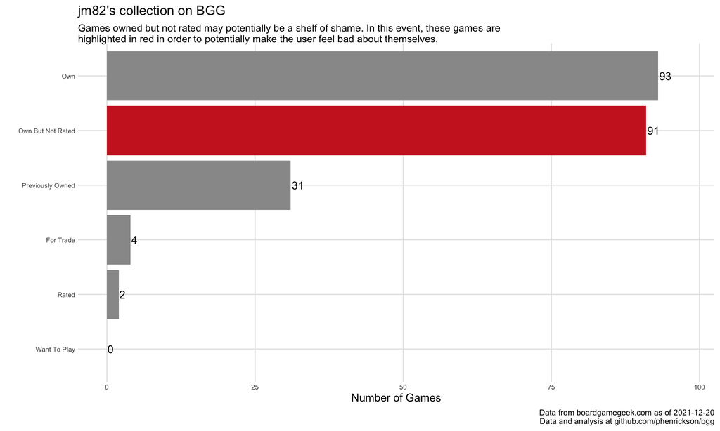

What years has the user owned/rated games from? While we can’t see when a user added or removed a game from their collection, we can look at their collection by the years in which their games were published.

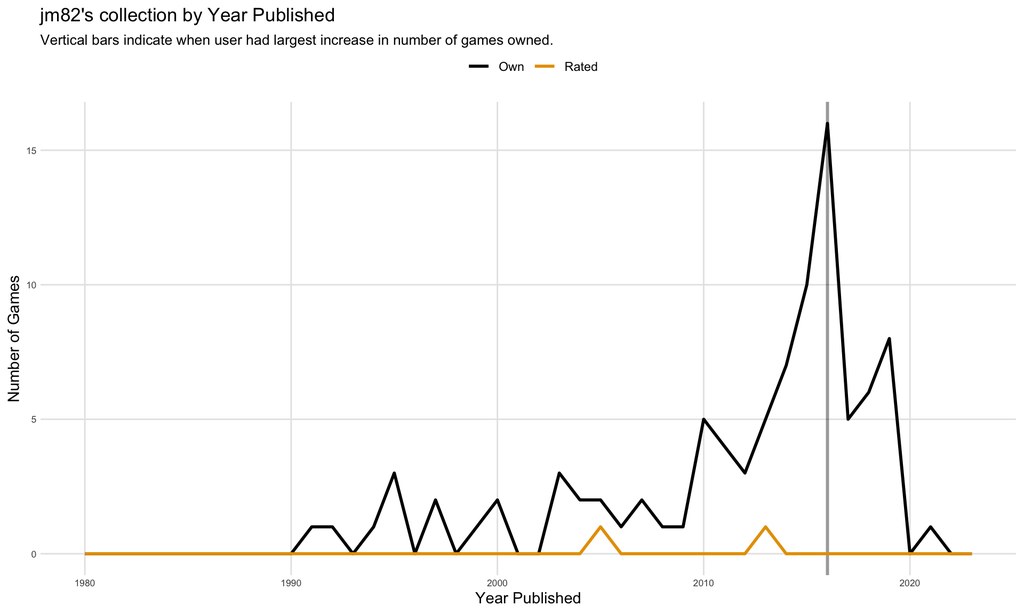

## 1.1 What types of games does jm82 own?

We can look at the most frequent types of categories, mechanics, designers, and artists that appear in a user’s collection.

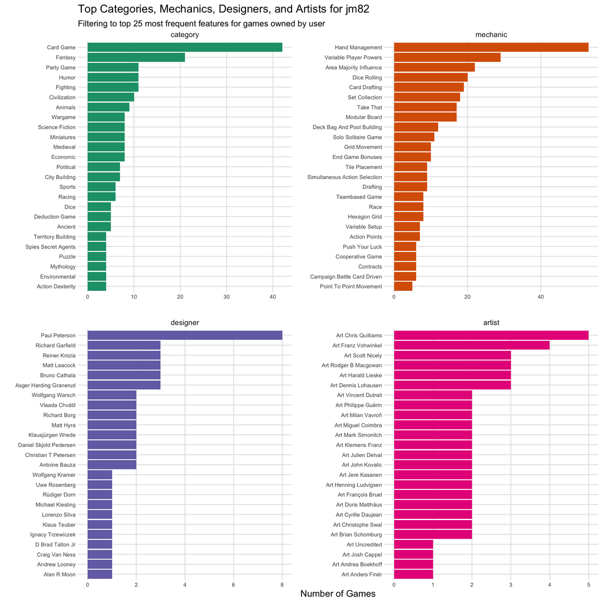

# 2 Modeling **jm82’s** Collection

| username | dataset | period | games_owned | games_rated | games_played |
| --- | --- | --- | --- | --- | --- |
| jm82 | training | published before 2018 | 77 | 2 | 108 |
| jm82 | test | published 2018 or later | 15 | 0 | 15 |

There are two main (binary) outcomes we will be modeling for the user.

The first, **own** refers to whether the user currently lists a game as owned in their collection. The second, **played** refers to whether the user currently owns, has rated, or previously owned a game. This means the latter will generally have a larger list of games, but may still be a useful category to examine for people who play lots of games without necessarily owning them.

We will train predictive models to learn the probability that the user will own or play individual games based on their features.

## 2.1 Coefficients for jm82

We can examine coefficients from the trained modes, which are penalized logistic regressions fit to our two main outcomes. Positive values indicate that a feature increases a user’s probabilility of owning/rating a game, while negative values indicate a feature decreases the probability.

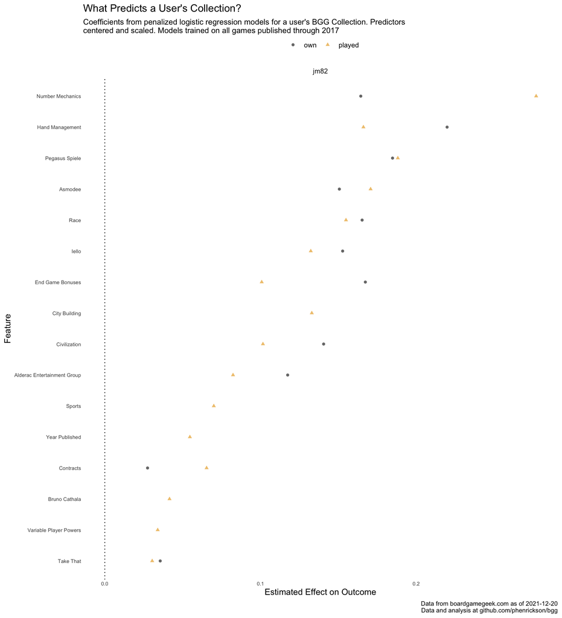

## 2.2 Visualizing Predictors for jm82’s Collection

Why did the model identify these features? We can make density plots of the important features for predicting whether the user owned a game. Blue indicates the density for games owned by the user, while grey indicates the density for games not owned by the user.

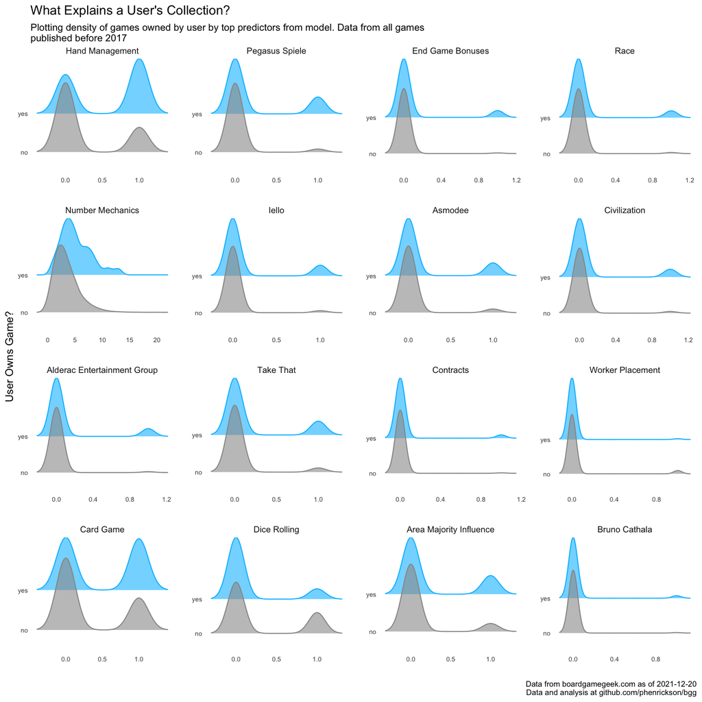

Binary predictors can be difficult to see with this visualization, so we can also directly examine the percentage of games in a user’s collection with a predictor vs the percentage of all games with that predictor.

| username | Feature | % of Games with Feature In_Collection | % of Games with Feature All_Games | Ratio |
| --- | --- | --- | --- | --- |
| jm82 | End Game Bonuses | 10.4% | 0.9% | 12.0 |
| jm82 | Alderac Entertainment Group | 11.7% | 1.5% | 8.0 |
| jm82 | Contracts | 5.2% | 0.7% | 7.3 |
| jm82 | Race | 10.4% | 1.6% | 6.4 |
| jm82 | Pegasus Spiele | 23.4% | 4.3% | 5.4 |
| jm82 | Iello | 15.6% | 2.9% | 5.4 |
| jm82 | Civilization | 11.7% | 2.4% | 4.8 |
| jm82 | Spies Secret Agents | 5.2% | 1.3% | 4.0 |
| jm82 | Asmodee | 18.2% | 5.1% | 3.6 |
| jm82 | Take That | 19.5% | 5.8% | 3.3 |
| jm82 | Video Game Theme | 5.2% | 1.6% | 3.3 |
| jm82 | Sports | 6.5% | 2.2% | 3.0 |
| jm82 | Deck Bag And Pool Building | 11.7% | 4.1% | 2.9 |
| jm82 | Fantasy Flight Games | 7.8% | 2.9% | 2.7 |
| jm82 | Area Majority Influence | 24.7% | 10.7% | 2.3 |
| jm82 | Hand Management | 58.4% | 26.3% | 2.2 |
| jm82 | Word Game | 3.9% | 1.8% | 2.2 |
| jm82 | Puzzle | 5.2% | 2.8% | 1.9 |
| jm82 | Card Game | 49.4% | 30.8% | 1.6 |
| jm82 | Party Game | 14.3% | 8.7% | 1.6 |
| jm82 | Horror | 3.9% | 3.7% | 1.0 |
| jm82 | Negotiation | 2.6% | 4.0% | 0.6 |
| jm82 | Dice Rolling | 14.3% | 28.9% | 0.5 |
| jm82 | Worker Placement | 1.3% | 5.2% | 0.2 |
| jm82 | Trivia | 0.0% | 2.0% | 0.0 |

# 3 Assess Model’s Performance on Training Set

Before predicting games in upcoming years, we can examine how well the model did and what games it liked in the training set. In this case, we used resampling techniques (cross validation) to ensure that the model had not seen a game before making its predictions.

## 3.1 Separation Plot

An easy way to examine the performance of classification model is to view a separation plot. We plot the predicted probabilities from the model for every game (from resampling) from lowest to highest. We then overlay a blue line for any game that the user does own. A good classifier is one that is able to *separate* the blue (games owned by the user) from the white (games not owned by the user), with most of the blue occurring at the highest probabilities (right side of the chart).

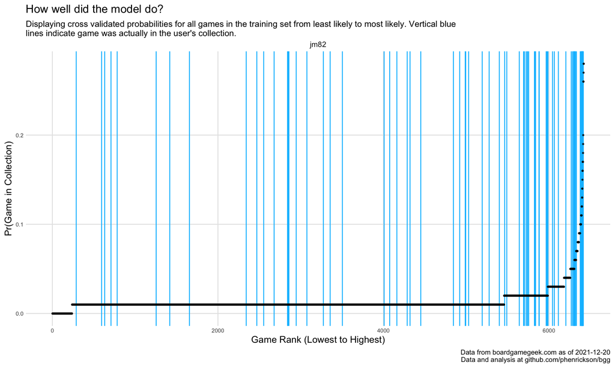

## 3.2 Top Games for **jm82** from Training Set

We can display this information in table form, displaying the 100 games with the highest probability of ownership, adding a blue line when the user does own the game.

| username | yearpublished | game_id | name | pred_played | pred_own | actual_played | actual_own |
| --- | --- | --- | --- | --- | --- | --- | --- |
| jm82 | 2013 | 52461 | Legacy: The Testament of Duke de Crecy | 0.26 | 0.28 | 0 | 0 |
| jm82 | 2011 | 88408 | Nightfall | 0.30 | 0.28 | 0 | 0 |
| jm82 | 2017 | 216658 | Smash Up: What Were We Thinking? | 0.29 | 0.27 | 0 | 0 |
| jm82 | 2013 | 134726 | Smash Up: Awesome Level 9000 | 0.04 | 0.26 | 1 | 1 |
| jm82 | 2017 | 216199 | Smash Up: Big in Japan | 0.27 | 0.26 | 0 | 0 |
| jm82 | 2005 | 18258 | Mission: Red Planet | 0.22 | 0.26 | 0 | 0 |
| jm82 | 2012 | 126163 | Tzolk'in: The Mayan Calendar | 0.10 | 0.20 | 0 | 0 |
| jm82 | 2011 | 70919 | Takenoko | 0.67 | 0.19 | 0 | 0 |
| jm82 | 2016 | 177590 | 13 Days: The Cuban Missile Crisis | 0.28 | 0.18 | 1 | 1 |
| jm82 | 2013 | 143185 | Smash Up: The Obligatory Cthulhu Set | 0.27 | 0.17 | 0 | 0 |
| jm82 | 1997 | 42 | Tigris & Euphrates | 0.16 | 0.17 | 0 | 0 |
| jm82 | 2015 | 162559 | Smash Up: Munchkin | 0.04 | 0.17 | 1 | 1 |
| jm82 | 2006 | 25613 | Through the Ages: A Story of Civilization | 0.14 | 0.17 | 0 | 0 |
| jm82 | 2010 | 62219 | Dominant Species | 0.18 | 0.16 | 0 | 0 |
| jm82 | 2014 | 148949 | Istanbul | 0.43 | 0.16 | 0 | 0 |
| jm82 | 1996 | 270 | Svea Rike | 0.07 | 0.16 | 0 | 0 |
| jm82 | 2015 | 182874 | Grand Austria Hotel | 0.23 | 0.15 | 0 | 0 |
| jm82 | 2012 | 122522 | Smash Up | 0.06 | 0.14 | 1 | 1 |
| jm82 | 2017 | 217861 | Paper Tales | 0.13 | 0.14 | 0 | 0 |
| jm82 | 2016 | 177802 | Smash Up: It's Your Fault! | 0.04 | 0.13 | 1 | 1 |
| jm82 | 2008 | 34635 | Stone Age | 0.13 | 0.13 | 0 | 0 |
| jm82 | 2014 | 151004 | Smash Up: Science Fiction Double Feature | 0.04 | 0.12 | 1 | 1 |
| jm82 | 2012 | 119391 | Il Vecchio | 0.13 | 0.12 | 0 | 0 |
| jm82 | 2016 | 199478 | Flamme Rouge | 0.30 | 0.12 | 1 | 1 |
| jm82 | 2017 | 230802 | Azul | 0.14 | 0.12 | 1 | 1 |
| jm82 | 2016 | 167791 | Terraforming Mars | 0.07 | 0.12 | 1 | 1 |
| jm82 | 2014 | 160018 | Smash Up: Monster Smash | 0.16 | 0.11 | 1 | 1 |
| jm82 | 2016 | 176083 | Hit Z Road | 0.09 | 0.11 | 0 | 0 |
| jm82 | 2015 | 176334 | Guns & Steel | 0.07 | 0.11 | 0 | 0 |
| jm82 | 2017 | 184921 | Bunny Kingdom | 0.04 | 0.11 | 0 | 0 |

[output cut: 70 more lines]

We can also more formally assess how well the model did in resampling by looking at the area under the receiver operating characteristic. A perfect model would receive a score of 1, while a model that cannot predict the outcome will default to a score of 0.5. The extent to which something is a *good* score depends on the setting, but generally anything in the .8 to .9 range is very good while the .7 to .8 range is perfectly acceptable.

| username | outcome_type | .metric | .estimator | .estimate |
| --- | --- | --- | --- | --- |
| jm82 | own | roc_auc | binary | 0.779 |
| jm82 | played | roc_auc | binary | 0.779 |

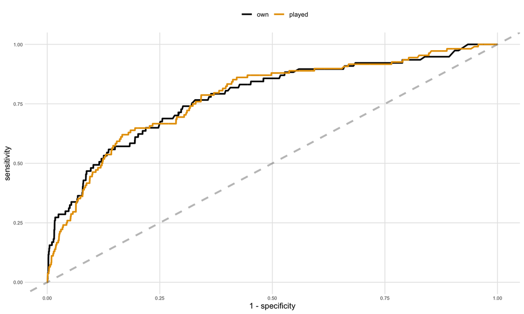

Another way to think about the model performance is to view its lift, or its ability to detect the positive outcomes over that of a null model. High lift indicates the model can much more quickly find all of the positive outcomes (in this case, games owned or played by the user), while a model with no lift is no better than random guessing.

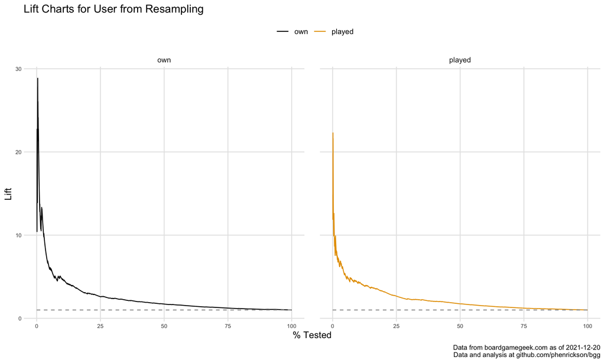

## 3.3 Most and Least Likely Games

What games does the model think jm82 is **most likely to own** that are **not** in their collection?

| username | yearpublished | game_id | name | pred_own | actual_own |
| --- | --- | --- | --- | --- | --- |
| jm82 | 2013 | 52461 | Legacy: The Testament of Duke de Crecy | 0.28 | 0 |
| jm82 | 2011 | 88408 | Nightfall | 0.28 | 0 |
| jm82 | 2017 | 216658 | Smash Up: What Were We Thinking? | 0.27 | 0 |
| jm82 | 2017 | 216199 | Smash Up: Big in Japan | 0.26 | 0 |
| jm82 | 2005 | 18258 | Mission: Red Planet | 0.26 | 0 |

What games does the model think jm82 is **least likely to own** that **are** in their collection?

| username | yearpublished | game_id | name | pred_own | actual_own |
| --- | --- | --- | --- | --- | --- |
| jm82 | 2013 | 146439 | BattleLore: Second Edition | 0.01 | 1 |
| jm82 | 2000 | 760 | Battle Line | 0.01 | 1 |
| jm82 | 2003 | 7717 | Carcassonne: The Castle | 0.01 | 1 |
| jm82 | 2014 | 160958 | DC Comics Deck-Building Game: Rivals – Batman vs The Joker | 0.01 | 1 |
| jm82 | 2007 | 27708 | 1960: The Making of the President | 0.01 | 1 |

## 3.4 Top Games by Year

Top 25 games most likely to be owned by the user in each year, highlighting in blue the games that the user has owned/played.

| rank | 2009 | 2010 | 2011 | 2012 | 2013 | 2014 | 2015 | 2016 | 2017 |
| --- | --- | --- | --- | --- | --- | --- | --- | --- | --- |
| 1 | Arcana | Dominant Species | Nightfall | Tzolk'in: The Mayan Calendar | Legacy: The Testament of Duke de Crecy | Istanbul | Smash Up: Munchkin | 13 Days: The Cuban Missile Crisis | Smash Up: What Were We Thinking? |
| 2 | Thunderstone | Troyes | Takenoko | Smash Up | Smash Up: Awesome Level 9000 | Smash Up: Science Fiction Double Feature | Grand Austria Hotel | Smash Up: It's Your Fault! | Smash Up: Big in Japan |
| 3 | EVE: Conquests | Sid Meier's Civilization: The Board Game | Mage Knight Board Game | Il Vecchio | Smash Up: The Obligatory Cthulhu Set | Smash Up: Monster Smash | Guns & Steel | Flamme Rouge | Paper Tales |
| 4 | Shipyard | Asteroyds | Eminent Domain | Love Letter | Guildhall: Job Faire | Valley of the Kings | Smash Up: Pretty Pretty Smash Up | Terraforming Mars | Azul |
| 5 | The Adventurers: The Temple of Chac | Puzzle Strike | Thunderstone: Dragonspire | Targi | Patchistory | Roll for the Galaxy | Epic PVP: Fantasy | Hit Z Road | Bunny Kingdom |
| 6 | Ra: The Dice Game | 7 Wonders | Nightfall: Martial Law | Terra Mystica | Thunderstone Advance: Numenera | Deus | Lost Legacy: Second Chronicle – Vorpal Sword & Whitegold Spire | Junta: Las Cartas | Gloomhaven |
| 7 | At the Gates of Loyang | Innovation | A Few Acres of Snow | Rent a Hero | Eight-Minute Empire: Legends | Alchemists | Why First? | Smash Up: Cease and Desist | Summit: The Board Game |
| 8 | Castle Panic | Expedition: Northwest Passage | 1911 Amundsen vs Scott | Archipelago | Circus Train (Second Edition) | Hyperborea | Star Realms: Colony Wars | Imhotep | Downforce |
| 9 | Infinite City | Merchants & Marauders | Discworld: Ankh-Morpork | Tokaido | Agent Hunter | Pagoda | The Bloody Inn | Yokohama | Lovecraft Letter |
| 10 | Hansa Teutonica | Keltis: Das Orakel | Eclipse | Clash of Cultures | Sail to India | Five Tribes | Mombasa | The Oracle of Delphi | Century: Spice Road |
| 11 | Cyclades | Leaping Lemmings | Panic Station | Kairo | Mush! Mush!: Snow Tails 2 | Spurs: A Tale in the Old West | Love Letter: The Hobbit – The Battle of the Five Armies | The Manhattan Project: Energy Empire | Gaia Project |
| 12 | Dungeon Twister 2: Prison | Onirim | Tales & Games: The Hare & the Tortoise | Santa Cruz | Race! Formula 90 | Akrotiri | Rush & Bash | Inis | Twilight Imperium: Fourth Edition |
| 13 | Dungeon Lords | Perplexus Epic | Drako: Dragon & Dwarves | Keyflower | Impulse | Imperial Settlers | Tiny Epic Galaxies | Aeon's End | Codenames: Duet |
| 14 | Heartland | Castaways | Village | Kemet | Sushi Go! | Splendor | Raptor | Mystic Vale | Lazer Ryderz |
| 15 | Pony Express | Myth: Pantheons | Mundus Novus | Yedo | Thunderstone: Starter Set | Camel Up | Haspelknecht | Scythe | Photosynthesis |
| 16 | Claustrophobia | Mai-Star | Dungeon Petz | The Manhattan Project | Hanamikoji | Three Kingdoms Redux | The Pursuit of Happiness | Agility | Spirit Island |
| 17 | Jaipur | Junta: Viva el Presidente! | Ninjato | Polis: Fight for the Hegemony | Tash-Kalar: Arena of Legends | The Ancient World | Far Space Foundry | Sakura Arms | Cutthroat Kingdoms |
| 18 | Assyria | Hanabi | Pastiche | Pixel Tactics | Salmon Run | Castles of Mad King Ludwig | Valley of the Kings: Afterlife | Islebound | Custom Heroes |
| 19 | Revolution! | Labyrinth: The War on Terror, 2001 – ? | Ascension: Storm of Souls | Suburbia | Empire Engine | Nations: The Dice Game | Mega Civilization | Captain Sonar | Michael Strogoff |
| 20 | Summoner Wars | Stalin's War | Munchkin Zombies | Trains | Euphoria: Build a Better Dystopia | Heroes of Normandie | Tides of Time | Sushi Go Party! | Santa Maria |
| 21 | Qwirkle Cubes | Elements | Dungeon Fighter | Guildhall | Munchkin Legends | Roll Through the Ages: The Iron Age | Brick Party | Codenames: Pictures | Pandemic Legacy: Season 2 |
| 22 | Atlantis | Cyrano | Munchkin Axe Cop | Robinson Crusoe: Adventures on the Cursed Island | Brew Crafters | Abyss | Karuba | Chariot Race | Breaking Bad: The Board Game |
| 23 | Rallyman | Zombie Dice | Colonial: Europe's Empires Overseas | Nightfall: The Coldest War | BioShock Infinite: The Siege of Columbia | Sheriff of Nottingham | Tales & Games: The Grasshopper & the Ant | Automobiles | Cartagena |
| 24 | Zoowaboo | Merkator | Pictomania | Thunderstone Advance: Towers of Ruin | Theseus: The Dark Orbit | Medieval Academy | OctoDice | Neolithic | Century: Golem Edition |
| 25 | Vasco da Gama | Key Market | Tem-Purr-A | Antike Duellum | 8 Masters' Revenge | The Battle of Five Armies | Through the Ages: A New Story of Civilization | Odin's Ravens (Second Edition) | 13 Minutes: The Cuban Missile Crisis, 1962 |

## 3.5 Interactive Predictions from Resampling

Interactive table for predictions from resampling.

|  | username | yearpublished | rank | game_id | name | pred_played | pred_own | actual_played | actual_own |
| --- | --- | --- | --- | --- | --- | --- | --- | --- | --- |
| 1 | jm82 | 1900 | 248 | 1602 | The Royal Game of Ur | 0.02 | 0.03 | 0 | 0 |
| 2 | jm82 | 1900 | 301 | 38950 | Halma | 0.02 | 0.03 | 0 | 0 |
| 3 | jm82 | 1900 | 355 | 15878 | Rummy | 0.04 | 0.03 | 0 | 0 |
| 4 | jm82 | 1900 | 369 | 2136 | Pachisi | 0.02 | 0.03 | 0 | 0 |
| 5 | jm82 | 1900 | 370 | 2386 | Chinese Checkers | 0.03 | 0.03 | 0 | 0 |
| 6 | jm82 | 1900 | 371 | 5432 | Chutes and Ladders | 0.03 | 0.03 | 0 | 0 |
| 7 | jm82 | 1900 | 384 | 2785 | Game of Goose | 0.04 | 0.03 | 0 | 0 |
| 8 | jm82 | 1900 | 978 | 11901 | Tic-Tac-Toe | 0.01 | 0.01 | 0 | 0 |
| 9 | jm82 | 1900 | 1018 | 188 | Go | 0.01 | 0.01 | 0 | 0 |
| 10 | jm82 | 1900 | 1119 | 171 | Chess | 0.01 | 0.01 | 0 | 0 |

[output cut: 6410 more lines]

# 4 Validating the Model on 2018

How well did a model trained on a user’s collection through 2017 perform in predicting games for the user from 2018?

| username | outcome_type | yearpublished | .metric | .estimator | .estimate |
| --- | --- | --- | --- | --- | --- |
| jm82 | own | 2018 | roc_auc | binary | 0.694 |
| jm82 | played | 2018 | roc_auc | binary | 0.701 |

Table of top 25 games from 2018, highlighting games that the user owns.

| username | yearpublished | game_id | name | pred_own | pred_played | actual_own | actual_played |
| --- | --- | --- | --- | --- | --- | --- | --- |
| jm82 | 2018 | 247763 | Underwater Cities | 0.31 | 0.35 | 0 | 0 |
| jm82 | 2018 | 205896 | Rising Sun | 0.19 | 0.27 | 0 | 0 |
| jm82 | 2018 | 241225 | Smash Up: That '70s Expansion | 0.18 | 0.16 | 0 | 0 |
| jm82 | 2018 | 247724 | Smash Up: Oops, You Did It Again | 0.18 | 0.16 | 0 | 0 |
| jm82 | 2018 | 199792 | Everdell | 0.15 | 0.22 | 0 | 0 |
| jm82 | 2018 | 232405 | Western Legends | 0.10 | 0.10 | 0 | 0 |
| jm82 | 2018 | 244711 | Newton | 0.10 | 0.10 | 0 | 0 |
| jm82 | 2018 | 245638 | Coimbra | 0.10 | 0.09 | 0 | 0 |
| jm82 | 2018 | 258444 | Gingerbread House | 0.10 | 0.13 | 0 | 0 |
| jm82 | 2018 | 256226 | Azul: Stained Glass of Sintra | 0.09 | 0.08 | 0 | 0 |
| jm82 | 2018 | 201509 | Dead Man's Doubloons | 0.07 | 0.11 | 0 | 0 |
| jm82 | 2018 | 238393 | Monolith Arena | 0.07 | 0.10 | 0 | 0 |
| jm82 | 2018 | 240892 | 8Bit Box | 0.07 | 0.12 | 0 | 0 |
| jm82 | 2018 | 313010 | Cosmic Encounter: 42nd Anniversary Edition | 0.07 | 0.13 | 0 | 0 |
| jm82 | 2018 | 222219 | Kero | 0.06 | 0.07 | 0 | 0 |
| jm82 | 2018 | 237182 | Root | 0.06 | 0.10 | 0 | 0 |
| jm82 | 2018 | 244331 | Blue Lagoon | 0.06 | 0.05 | 0 | 0 |
| jm82 | 2018 | 246297 | Shadows: Amsterdam | 0.06 | 0.12 | 0 | 0 |
| jm82 | 2018 | 242574 | Century: Eastern Wonders | 0.05 | 0.13 | 0 | 0 |
| jm82 | 2018 | 245643 | Luxor | 0.05 | 0.07 | 0 | 0 |
| jm82 | 2018 | 245928 | Pax Emancipation | 0.05 | 0.06 | 0 | 0 |
| jm82 | 2018 | 209324 | The World of SMOG: Rise of Moloch | 0.04 | 0.08 | 0 | 0 |
| jm82 | 2018 | 215341 | Thunderstone Quest | 0.04 | 0.03 | 0 | 0 |
| jm82 | 2018 | 218509 | Empires of the Void II | 0.04 | 0.06 | 0 | 0 |
| jm82 | 2018 | 223321 | Detective: A Modern Crime Board Game | 0.04 | 0.05 | 0 | 0 |

# 5 Predicting Upcoming Games (2018 and On) for **jm82**

Examine the top games for the test set.

| username | yearpublished | game_id | name | rank | own | played |
| --- | --- | --- | --- | --- | --- | --- |
| jm82 | 2018 | 247763 | Underwater Cities | 1 | 0.31 | 0.35 |
| jm82 | 2018 | 205896 | Rising Sun | 2 | 0.19 | 0.27 |
| jm82 | 2018 | 241225 | Smash Up: That '70s Expansion | 3 | 0.18 | 0.16 |
| jm82 | 2018 | 247724 | Smash Up: Oops, You Did It Again | 4 | 0.18 | 0.16 |
| jm82 | 2018 | 199792 | Everdell | 5 | 0.15 | 0.22 |
| jm82 | 2018 | 232405 | Western Legends | 6 | 0.10 | 0.10 |
| jm82 | 2018 | 245638 | Coimbra | 7 | 0.10 | 0.09 |
| jm82 | 2018 | 258444 | Gingerbread House | 8 | 0.10 | 0.13 |
| jm82 | 2018 | 244711 | Newton | 9 | 0.10 | 0.10 |
| jm82 | 2018 | 256226 | Azul: Stained Glass of Sintra | 10 | 0.09 | 0.08 |
| jm82 | 2018 | 240892 | 8Bit Box | 11 | 0.07 | 0.12 |
| jm82 | 2018 | 313010 | Cosmic Encounter: 42nd Anniversary Edition | 12 | 0.07 | 0.13 |
| jm82 | 2018 | 201509 | Dead Man's Doubloons | 13 | 0.07 | 0.11 |
| jm82 | 2018 | 238393 | Monolith Arena | 14 | 0.07 | 0.10 |
| jm82 | 2018 | 244331 | Blue Lagoon | 15 | 0.06 | 0.05 |
| jm82 | 2018 | 237182 | Root | 16 | 0.06 | 0.10 |
| jm82 | 2018 | 246297 | Shadows: Amsterdam | 17 | 0.06 | 0.12 |
| jm82 | 2018 | 222219 | Kero | 18 | 0.06 | 0.07 |
| jm82 | 2018 | 245643 | Luxor | 19 | 0.05 | 0.07 |
| jm82 | 2018 | 245928 | Pax Emancipation | 20 | 0.05 | 0.06 |
| jm82 | 2018 | 242574 | Century: Eastern Wonders | 21 | 0.05 | 0.13 |
| jm82 | 2018 | 249259 | War Chest | 22 | 0.04 | 0.04 |
| jm82 | 2018 | 244114 | Yellow & Yangtze | 23 | 0.04 | 0.04 |
| jm82 | 2018 | 242639 | Treasure Island | 24 | 0.04 | 0.06 |
| jm82 | 2018 | 215341 | Thunderstone Quest | 25 | 0.04 | 0.03 |
| jm82 | 2019 | 270971 | Era: Medieval Age | 1 | 0.47 | 0.63 |
| jm82 | 2019 | 265736 | Tiny Towns | 2 | 0.28 | 0.41 |
| jm82 | 2019 | 260710 | Amul | 3 | 0.23 | 0.27 |
| jm82 | 2019 | 283863 | The Magnificent | 4 | 0.20 | 0.36 |
| jm82 | 2019 | 271324 | It's a Wonderful World | 5 | 0.18 | 0.13 |
| jm82 | 2019 | 276025 | Maracaibo | 6 | 0.17 | 0.28 |
| jm82 | 2019 | 270844 | Imperial Settlers: Empires of the North | 7 | 0.16 | 0.27 |
| jm82 | 2019 | 287954 | Azul: Summer Pavilion | 8 | 0.10 | 0.08 |
| jm82 | 2019 | 257066 | Sierra West | 9 | 0.10 | 0.11 |
| jm82 | 2019 | 274364 | Watergate | 10 | 0.09 | 0.11 |
| jm82 | 2019 | 266507 | Clank!: Legacy – Acquisitions Incorporated | 11 | 0.09 | 0.14 |
| jm82 | 2019 | 269144 | Hadara | 12 | 0.09 | 0.11 |
| jm82 | 2019 | 284435 | Nova Luna | 13 | 0.08 | 0.15 |
| jm82 | 2019 | 266938 | Smash Up: World Tour – International Incident | 14 | 0.08 | 0.06 |
| jm82 | 2019 | 270836 | Imperial Settlers: Roll & Write | 15 | 0.08 | 0.14 |
| jm82 | 2019 | 256730 | Pipeline | 16 | 0.07 | 0.09 |
| jm82 | 2019 | 270168 | Tuki | 17 | 0.07 | 0.11 |
| jm82 | 2019 | 251247 | Barrage | 18 | 0.07 | 0.12 |
| jm82 | 2019 | 258210 | Blitzkrieg!: World War Two in 20 Minutes | 19 | 0.07 | 0.10 |
| jm82 | 2019 | 264982 | Coloma | 20 | 0.07 | 0.12 |
| jm82 | 2019 | 266192 | Wingspan | 21 | 0.07 | 0.06 |
| jm82 | 2019 | 274590 | Smash Up: World Tour – Culture Shock | 22 | 0.07 | 0.07 |
| jm82 | 2019 | 280480 | Crystal Palace | 23 | 0.06 | 0.05 |
| jm82 | 2019 | 240567 | Chocolate Factory | 24 | 0.06 | 0.07 |
| jm82 | 2019 | 270673 | Silver & Gold | 25 | 0.06 | 0.07 |
| jm82 | 2020 | 320819 | Dinner in Paris | 1 | 0.30 | 0.32 |
| jm82 | 2020 | 311193 | Anno 1800 | 2 | 0.27 | 0.29 |
| jm82 | 2020 | 302310 | Nanaki | 3 | 0.18 | 0.22 |
| jm82 | 2020 | 184267 | On Mars | 4 | 0.17 | 0.42 |
| jm82 | 2020 | 256317 | Guild Master | 5 | 0.16 | 0.21 |
| jm82 | 2020 | 300322 | Hallertau | 6 | 0.11 | 0.17 |
| jm82 | 2020 | 279198 | Tungaru | 7 | 0.10 | 0.07 |
| jm82 | 2020 | 296151 | Viscounts of the West Kingdom | 8 | 0.09 | 0.08 |
| jm82 | 2020 | 298572 | Cosmic Encounter Duel | 9 | 0.09 | 0.14 |
| jm82 | 2020 | 245658 | Unicorn Fever | 10 | 0.09 | 0.12 |
| jm82 | 2020 | 246900 | Eclipse: Second Dawn for the Galaxy | 11 | 0.08 | 0.15 |
| jm82 | 2020 | 298371 | Wild Space | 12 | 0.07 | 0.05 |
| jm82 | 2020 | 291874 | Dwergar | 13 | 0.07 | 0.06 |
| jm82 | 2020 | 253506 | Versailles 1919 | 14 | 0.06 | 0.05 |
| jm82 | 2020 | 308765 | Praga Caput Regni | 15 | 0.06 | 0.09 |
| jm82 | 2020 | 307844 | Atheneum: Mystic Library | 16 | 0.06 | 0.07 |
| jm82 | 2020 | 298018 | Memorinth | 17 | 0.06 | 0.08 |
| jm82 | 2020 | 299960 | Alma Mater | 18 | 0.06 | 0.04 |
| jm82 | 2020 | 302840 | Carcata | 19 | 0.06 | 0.06 |
| jm82 | 2020 | 316377 | 7 Wonders (Second Edition) | 20 | 0.06 | 0.15 |
| jm82 | 2020 | 277927 | Bites | 21 | 0.05 | 0.04 |
| jm82 | 2020 | 313698 | Monster Expedition | 22 | 0.05 | 0.05 |
| jm82 | 2020 | 294484 | Unmatched: Cobble & Fog | 23 | 0.05 | 0.07 |
| jm82 | 2020 | 299592 | Beez | 24 | 0.05 | 0.12 |
| jm82 | 2020 | 227224 | The Red Cathedral | 25 | 0.05 | 0.05 |

## 5.1 Interactive Table for Upcoming Games 2018 and On

|  | username | yearpublished | game_id | name | rank | own | played |
| --- | --- | --- | --- | --- | --- | --- | --- |
| 1 | jm82 | 2019 | 270971 | Era: Medieval Age | 1 | 0.47 | 0.63 |
| 2 | jm82 | 2018 | 247763 | Underwater Cities | 2 | 0.31 | 0.35 |
| 3 | jm82 | 2020 | 320819 | Dinner in Paris | 3 | 0.3 | 0.32 |
| 4 | jm82 | 2019 | 265736 | Tiny Towns | 4 | 0.28 | 0.41 |
| 5 | jm82 | 2020 | 311193 | Anno 1800 | 5 | 0.27 | 0.29 |
| 6 | jm82 | 2019 | 260710 | Amul | 6 | 0.23 | 0.27 |
| 7 | jm82 | 2019 | 283863 | The Magnificent | 7 | 0.2 | 0.36 |
| 8 | jm82 | 2018 | 205896 | Rising Sun | 8 | 0.19 | 0.27 |
| 9 | jm82 | 2019 | 271324 | It's a Wonderful World | 9 | 0.18 | 0.13 |
| 10 | jm82 | 2020 | 302310 | Nanaki | 10 | 0.18 | 0.22 |

[output cut: 1923 more lines]